# Redefining Marketing Research: Data Science & AI

Group 10 - Eder Garcia, Dusty Vela

2026-04-22

# 1 Introduction

This document provides a quantitative analysis of the global **Marketing Research** industry and its ongoing transformation toward **Data Science**. All data were compiled from ESOMAR, Statista, McKinsey, Qualtrics, and The Business Research Company (2022–2025).

> *“Data science is fast becoming the new look of marketing research.”* — Miller, Modeling Techniques in Predictive Analytics

# 2 Global Industry Growth

## 2.1 Global Revenue 2008–2024

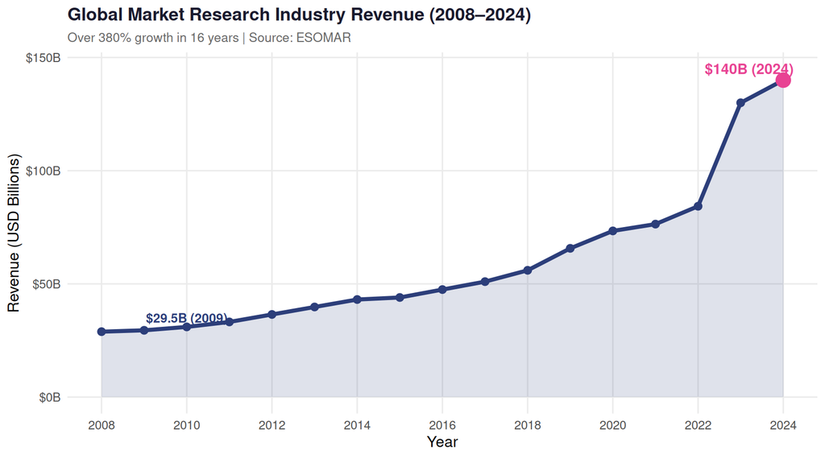

## 2.2 Revenue by Region (2022)

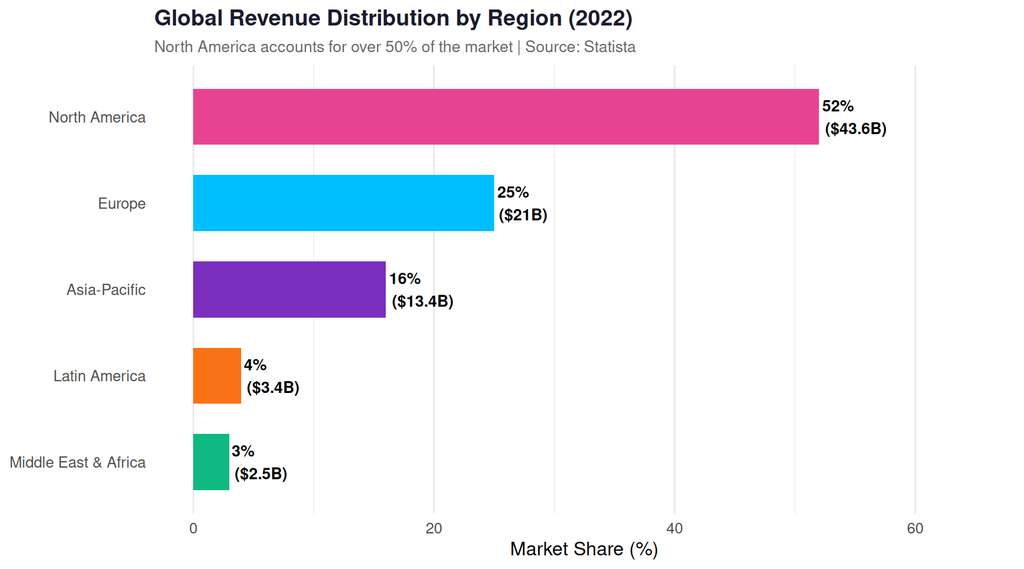

## 2.3 Top Companies by Revenue

Top Global Market Research Companies | Source: Statista / ESOMAR 2022

| Company | Country | Research Revenue | Year | Specialty |
| --- | --- | --- | --- | --- |
| Gartner | USA | $5.48B | 2022 | Business Intelligence |
| IQVIA | USA | $5.43B | 2022 | Healthcare Analytics |
| Salesforce | USA | $4.52B | 2022 | CRM & Analytics |
| Kantar | UK | $3.7B | 2022 | Consumer Data & Consulting |
| Nielsen Holdings | USA | $3.5B | 2022 | Retail & Media Measurement |
| Ipsos | Francia | $2.15B | 2022 | Public Opinion & Research |
| GfK | Alemania | $1.9B | 2022 | Consumer & Market Intelligence |

# 3 Porter’s Five Forces Analysis

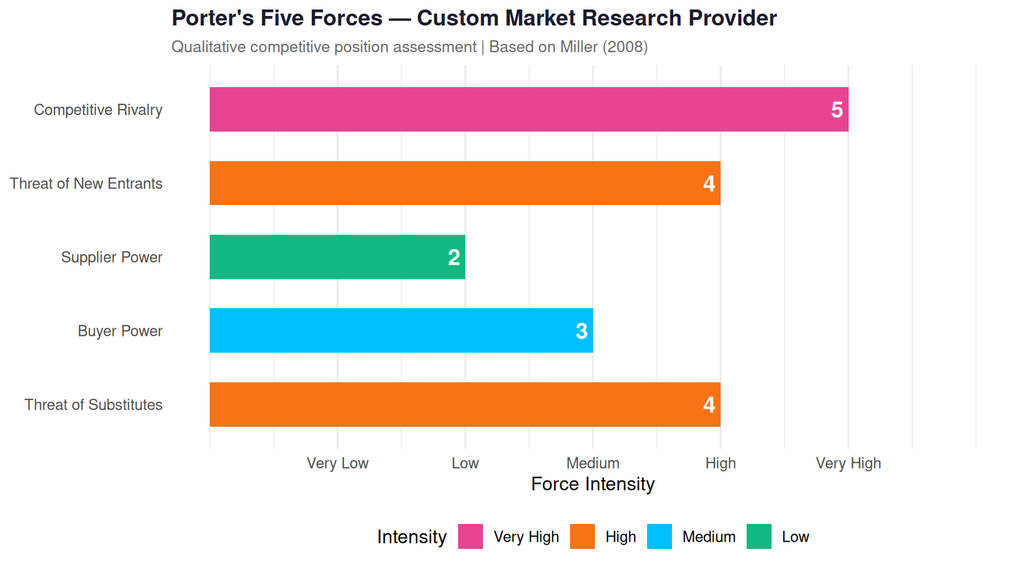

Porter’s Five Forces Summary | Custom Research Provider

| Force | Intensity | Key Factors |
| --- | --- | --- |
| Competitive Rivalry | Very High | Miles de firmas compiten; márgenes bajos; pocos proyectos exclusivos |
| Threat of New Entrants | High | IT firms, consultoras y advertising firms pueden entrar fácilmente |
| Supplier Power | Low | Alta oferta de labor y tecnología; proveedores sin poder individual |
| Buyer Power | Medium | Muchos compradores pero contratos cortos; pueden cambiar de proveedor |
| Threat of Substitutes | High | DIY research (Qualtrics/SurveyMonkey) + datos secundarios + IA generativa |

# 4 Traditional vs. Digital Research Methods

## 4.1 Method Usage Rate

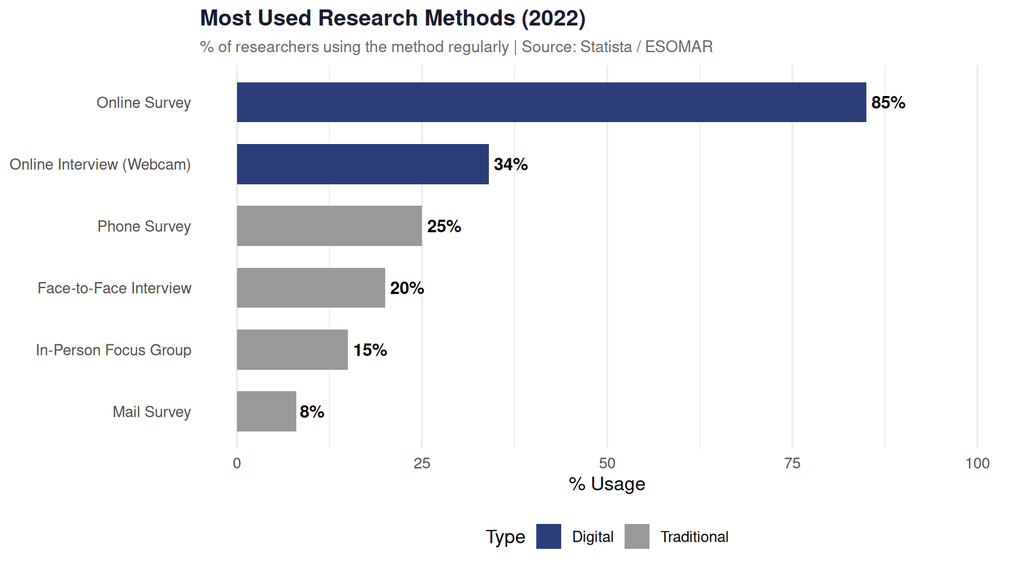

## 4.2 Revenue by Service Type

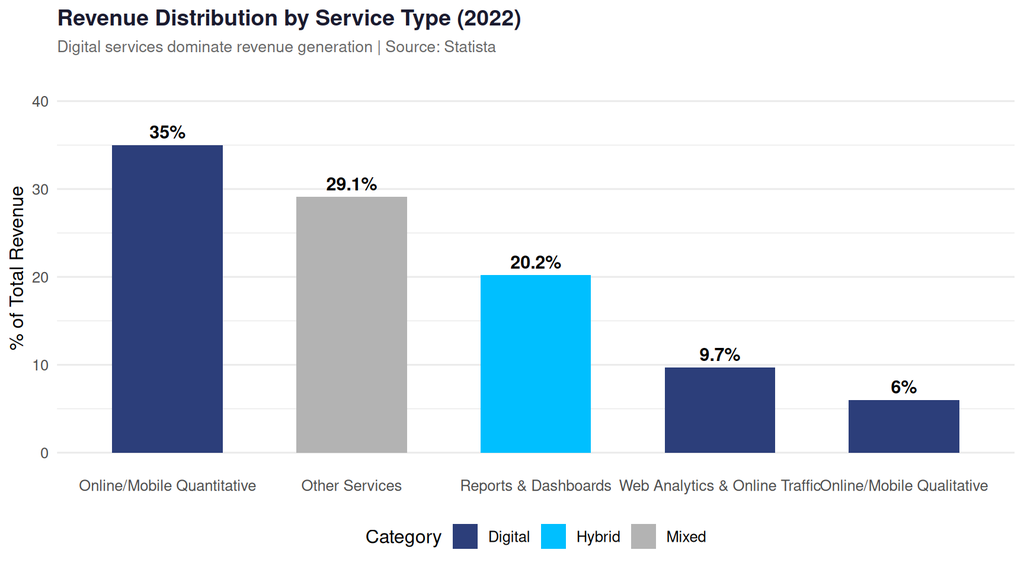

## 4.3 Survey Response Rates: Historical Decline & Comparison

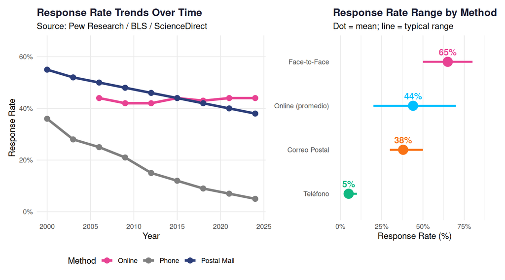

# 5 AI Adoption in Marketing Research

## 5.1 AI Adoption by Business Function (2023 vs. 2024)

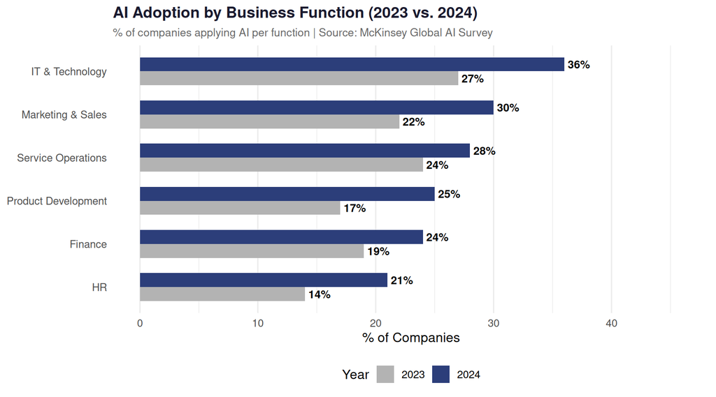

## 5.2 AI in Marketing Research: Key Metrics

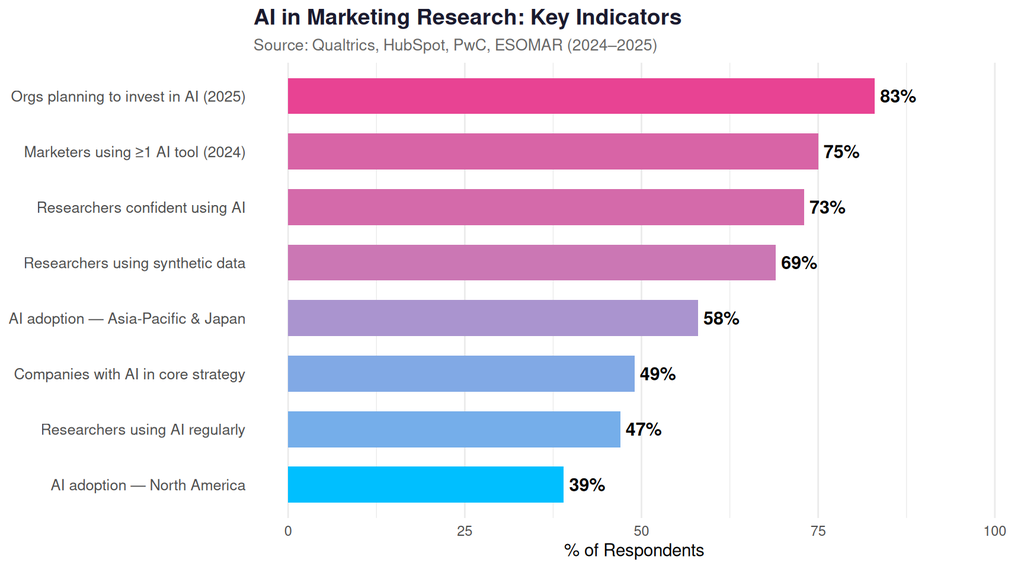

## 5.3 AI in Marketing Market Size Forecast (2021–2028)

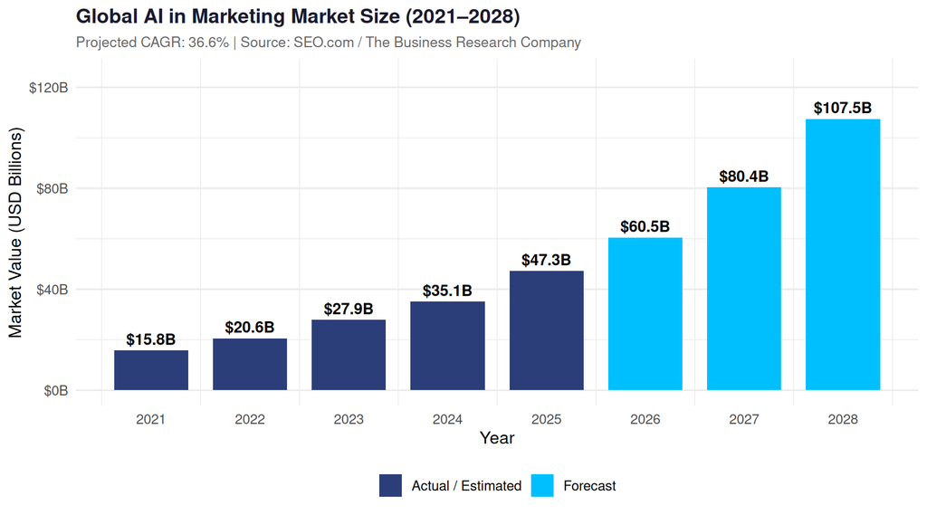

# 6 Summary & Conclusions

Key KPIs — Marketing Research & Data Science Industry

[output not shown]

## 6.1 Key Findings

**1. The industry is growing rapidly** Global market research revenue rose from $29.5B in 2009 to $140B in 2024 — a sustained expansion driven by digitalization and rising demand for competitive intelligence.

**2. High competitive pressure (Porter)** Custom research providers operate in a highly competitive market with low barriers to entry. Differentiation through specialized expertise and technology is the only sustainable path.

**4. AI: from optional tool to strategic necessity** 47% of researchers already use AI regularly, and 83% plan to invest in it by 2025. The AI-in-marketing market will grow from $47B (2025) to $107B (2028).

**5. Response rates remain a persistent challenge** Despite digital growth, online surveys average only a 44% response rate. Instrument design and precise population targeting are the most critical improvement levers.

## 6.2 Hypothesis

**“Marketing research firms that shift their value proposition from data collection to data interpretation — leveraging digital tools and AI — will achieve sustainable competitive advantage, while those anchored to traditional primary research methods will face structural decline.”**

### 6.2.1 Theoretical Foundation

This hypothesis builds directly on Miller’s argument that firms failed by defining themselves by *how* they collected data rather than the *value* they delivered. Porter’s Five Forces reinforces it: in a market with high rivalry and low barriers to entry, the only escape from price competition is meaningful differentiation through expertise and technology.

### 6.2.2 What the Data Supports

- **Growth ≠ survival.** The industry grew 380% from 2009 to 2024, but Porter’s analysis shows this growth is not shared equally — it rewards differentiators, not the industry as a whole.
- **Traditional methods are in structural decline.** Phone survey response rates collapsed from 36% to 5% in two decades. Firms still investing in traditional data collection are building on a shrinking foundation.
- **AI is becoming the baseline, not the differentiator.** With 47% of researchers already using AI and 83% planning to invest by 2025, firms that adopt late will use AI just to keep up — not to lead.
- **Quality gaps create opportunity.** A 44% online response rate means volume and convenience alone do not solve the research quality problem — that gap is exactly where human expertise and rigorous methodology still create irreplaceable value.

### 6.2.3 Bottom Line

The firms that survive are not those who do research *cheaper* — they are those who deliver *smarter intelligence*. The data, the book, and Porter all point to the same conclusion: in this industry, value is created at the interpretation layer, not the collection layer.

## 6.3 AI is Revolutionizing Marketing Research

### 6.3.1 AI in Business Today

Artificial Intelligence is no longer a future concept — it is actively reshaping how businesses operate right now. According to McKinsey (2024), **78% of organizations** already use AI in at least one business function, up from just 55% a year before. Companies are not experimenting anymore — they are deploying.

The numbers tell the story clearly:

- The global AI market reached **$638B in 2024** and is projected to hit **$1.81 trillion by 2030**
- Businesses using AI in marketing and sales report **5–10% revenue growth** directly linked to it
- **92% of firms** plan to increase their AI budgets within the next three years
- AI tools save marketing teams an average of **2.5 hours per day** per employee

AI is now present in every major business function — from finance and HR to operations and customer service. But perhaps nowhere is its impact more transformative than in **marketing research.**

### 6.3.2 How AI is Changing Marketing Research Specifically

Traditional marketing research was slow, expensive, and limited by human capacity — you could only interview so many people, analyze so many surveys, and process so much data. AI removes those constraints entirely.

**Speed.** Tasks that used to take weeks — fielding a survey, cleaning data, running analysis, writing a report — can now be compressed into hours. AI-powered platforms like Qualtrics and Kantar’s new insights engine deliver real-time consumer intelligence that updates continuously rather than in quarterly reports.

**Scale.** AI can analyze millions of social media posts, customer reviews, and online conversations simultaneously — a form of passive, always-on research that was simply impossible before. This transforms research from a project into a continuous feed of intelligence.

**Synthetic Data.** One of the most disruptive developments is the rise of synthetic data — AI-generated respondents that simulate real consumer behavior. Already **69% of researchers** are incorporating synthetic data into their work, allowing firms to test hypotheses without recruiting a single real participant.

**Predictive Intelligence.** AI does not just describe what happened — it predicts what will happen. Predictive analytics models now allow firms to anticipate consumer trends, simulate market scenarios, and recommend strategic actions before a problem even surfaces.

### 6.3.3 What This Means for the Industry

The data in this analysis makes the stakes clear. The AI-in-marketing market is growing at a **36.6% annual rate**, from $47B in 2025 to a projected $107B in 2028. With **83% of research organizations** planning to invest in AI by 2025, it is rapidly shifting from competitive advantage to baseline expectation.

The firms that embrace AI as an interpretation and intelligence tool — not just an automation shortcut — will define the next era of marketing research. The firms that do not will find themselves exactly where Miller warned: defined by what they do, not the value they create.

> *“AI does not replace the researcher. It removes the ceiling on what a researcher can do.”*

# 7 Discussion Questions & Answers

**Q1. The industry grew 380% from 2009 to 2024. What forces drove this and will it continue?**

**A:** The main drivers were the rise of digital data, e-commerce, social media, and the shift to scalable online research methods that lowered costs for both buyers and sellers. Globalization also pushed firms to understand new markets. Future growth will likely slow — the projected CAGR of 4.6% through 2030 is much more moderate than the explosive 2021–2024 pace, which was partly inflated by post-pandemic digital transformation and early AI investment.

**Q2. Competitive Rivalry is rated Very High with thin margins. If you were launching a research firm today, what would your strategy be?**

**A:** You cannot compete on price or breadth against established players. The winning move is specialization — either by industry (become the go-to firm for healthcare or fintech research), by methodology (build proprietary AI tools that generate insights faster), or by owning a unique respondent community no competitor can replicate. The core lesson from the analysis is that firms defined by *what they do* (surveys, focus groups) die. Firms defined by the *value they add* (insight, strategy, foresight) survive.

**Q3. Online surveys have 85% adoption but only a 44% response rate. Does high adoption mean high quality?**

**A:** No — adoption and quality are very different things. The ease and low cost of online surveys explains the 85% adoption, but a 44% response rate means over half the target population isn’t responding, which creates serious non-response bias. The people who respond may systematically differ from those who don’t, skewing results in ways researchers may not detect. This is precisely where professional expertise still matters over DIY tools — rigorous sampling design and bias testing are not built into a SurveyMonkey account.

## 7.1 AI-Assisted Development: Reflections

### 7.1.1 How We Used AI

During the development of this R Markdown analysis, we used **ChatGPT** and **Claude** as support tools. They helped us generate `ggplot2` chart templates, debug cryptic error messages, and structure the narrative sections like the hypothesis and discussion questions.

The most valuable use was debugging — when `pivot_longer()` threw a duplicate column name error, pasting it into Claude produced the root cause and a fix in seconds.

### 7.1.2 What AI Got Wrong

AI was not a plug-and-play solution. Key issues we ran into:

- Generated code that **looked correct but would not run** — wrong argument names, deprecated functions, incompatible combinations.
- **Lost context** in long sessions and started contradicting earlier code decisions.
- Gave **wrong answers confidently** — with no signal that it was uncertain.

Every single AI-generated code block had to be tested and verified manually before use.

### 7.1.3 The Bottom Line

> *AI is a skilled assistant, not an expert.* It speeds up execution — but you still need to do the thinking.

The best workflow we found: **think first, use AI to execute faster, verify everything.**

### 7.1.4 Class Discussion

- Have you used AI for coding or analysis tasks? Did it save time or create more problems?
- Where do you think the line is between using AI as a tool vs. relying on it too much?

# 8 References

- ESOMAR. (2024). *Global Market Research 2024 Report*. https://shop.esomar.org
- Statista. (2024). *Market Research Industry — Statistics & Facts*. https://www.statista.com
- McKinsey & Company. (2025). *The State of AI in 2025*. https://www.mckinsey.com
- Qualtrics. (2024). *Market Research Trends Report 2024*. https://www.qualtrics.com
- Wu, M.-J. et al. (2022). Response rates of online surveys: A meta-analysis. *Computers in Human Behavior Reports*, 7. https://doi.org/10.1016/j.chbr.2022.100206
- Miller, T. W. (2015). *Modeling Techniques in Predictive Analytics*. Pearson.
- Porter, M. E. (1980). *Competitive Strategy*. Free Press.
- The Business Research Company. (2024). *Market Research Services Global Market Report 2024*.